# Utilizando o R para Inferência Estatística

Cristiano de Carvalho Santos - Departamento de Estatística da UFMG

## Métodos de Inferência

A Inferência estatística tem como objetivo estudar generalizações sobre uma população através de evidências fornecidas por uma amostra retirada desta população.

E os dois principais tipos de inferência são:

- Estimação Pontual e Intervalar;
- Testes de Hipóteses.

Quantidades de interesse:

- Para a média;
- Para a variância;
- Para a proporção;
- Entre outros.

Veremos como minizar/maximizar funções, contruir intervalos de confiança e fazer testes de hipóteses!

## Minimizando ou maximizando uma função

## Minimizando ou maximizando uma função

Quando minimizar ou maximizar funções pode ser útil dentro da inferência estatística?

- Para encontrar estimadores de mínimos quadrados ou de máxima verossimilhança, por exemplo.

A função *optim* pode ser utilizada para encontrar os valores que minimizam uma função.

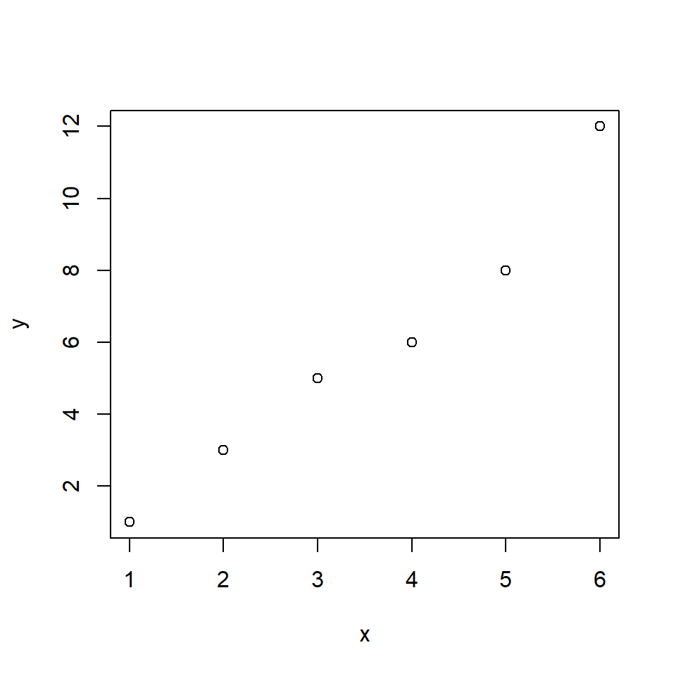

```r
## Criando dados e fazendo um diagrama de dispersão.
dat=data.frame(x=c(1, 2, 3, 4, 5, 6),
               y=c(1, 3, 5, 6, 8, 12))
with(dat, plot(x, y))
```

Minimizando soma dos resíduos ao quadrado:

```r
## Função que calcula soma do quadrado dos resíduos
min.RSS <- function(data, par) {
  with(data, sum((par[1] + par[2] * x - y)^2))
}

## Minimizando a soma do quadrado dos resíduos
# Note que eh necessario informar um vetor com valores iniciais
result <- optim(par = c(0, 1), min.RSS, data = dat)
result
```

```
## $par
## [1] -1.266846  2.028620
##
## $value
## [1] 2.819048
##
## $counts
## function gradient
##       89       NA
##
## $convergence
## [1] 0
##
## $message
## NULL
```

```r
## Comparando com a função pronta para ajustar um modelo de regressão linear
lm(y ~ x, data = dat)
```

```
##
## Call:
## lm(formula = y ~ x, data = dat)
##
## Coefficients:
## (Intercept)            x
##      -1.267        2.029
```

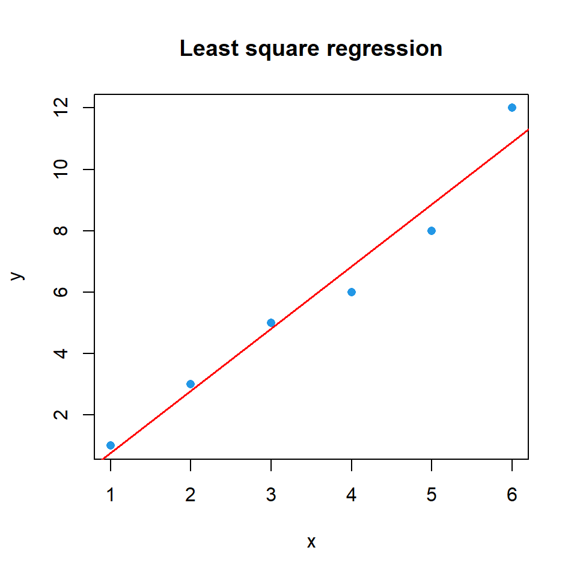

```r
## Gráfico de dispersão com reta ajustada
plot(y ~ x, data = dat, main="Least square regression", pch=16, col=4)
abline(a = result$par[1], b = result$par[2], col = "red", lwd=1.5)
```

### Outro exemplo informando o gradiente da função

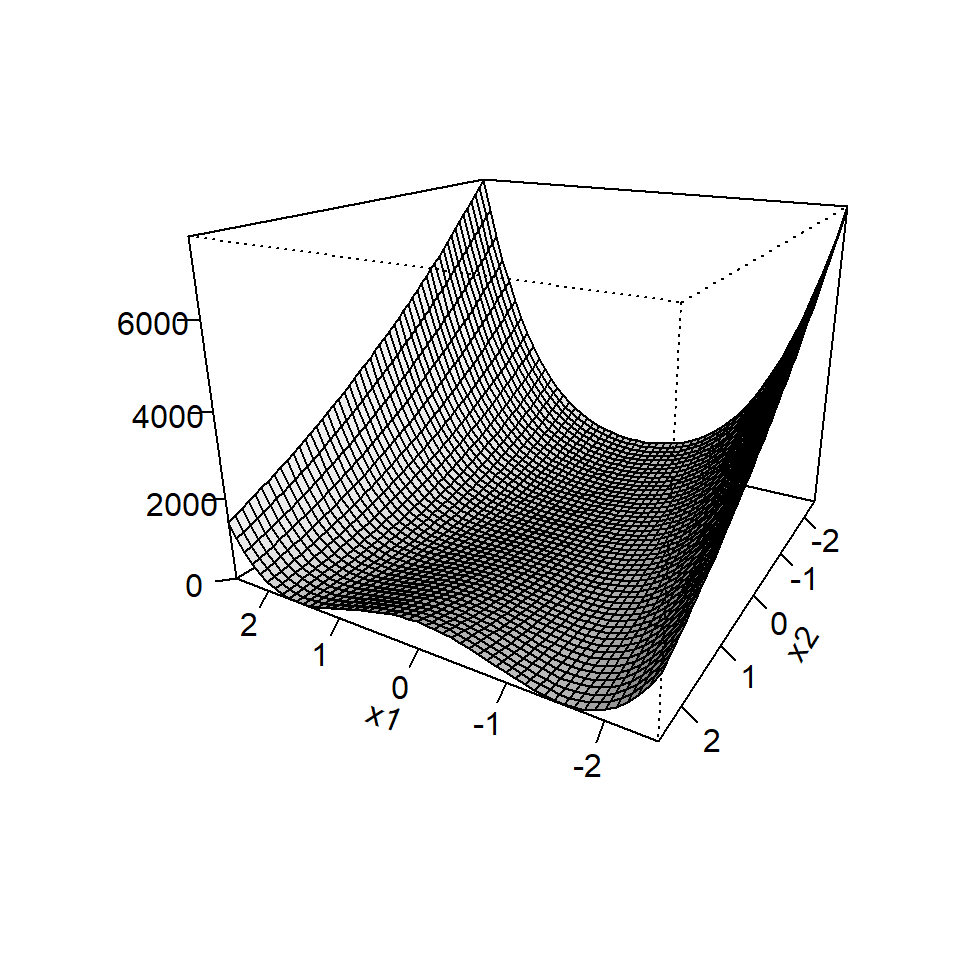

```r
fr <- function(x) {   ## Rosenbrock Banana function
  x1 <- x[1]
  x2 <- x[2]
  100 * (x2 - x1 * x1)^2 + (1 - x1)^2
}
grr <- function(x) { ## Gradient of 'fr'
  x1 <- x[1]
  x2 <- x[2]
  c(-400 * x1 * (x2 - x1 * x1) - 2 * (1 - x1),
    200 *      (x2 - x1 * x1))
}


## Grafico da função que desejamos minimizar
x1 = x2 = seq(-2.5, 2.5, by=0.1)
a = expand.grid(x=x1, y=x2)
y = matrix(fr(a)[[1]], nrow=length(x1), ncol=length(x2))


persp(x1, x2, y, theta = 210, phi = 20, expand = 0.75, d=1, zlab="",
      shade = 0.5, ticktype = "detailed", r=2)
```

```r
#  Gráfico Interativo
#require(rgl)
#x11()
#op <- par(bg = "white")
#open3d()
#persp3d(x1, x2, y, expand = 0.25, zlab="", main=" ",
 #       xlab=expression(nu[1]), ylab=expression(nu[2]), col=2)

## minimizando
optim(c(-1.2, 1), fr)
```

```
## $par
## [1] 1.000260 1.000506
##
## $value
## [1] 8.825241e-08
##
## $counts
## function gradient
##      195       NA
##
## $convergence
## [1] 0
##
## $message
## NULL
```

```r
res <- optim(c(-1.2, 1), fr, grr, method = "BFGS")
res
```

```
## $par
## [1] 1 1
##
## $value
## [1] 9.594956e-18
##
## $counts
## function gradient
##      110       43
##
## $convergence
## [1] 0
##
## $message
## NULL
```

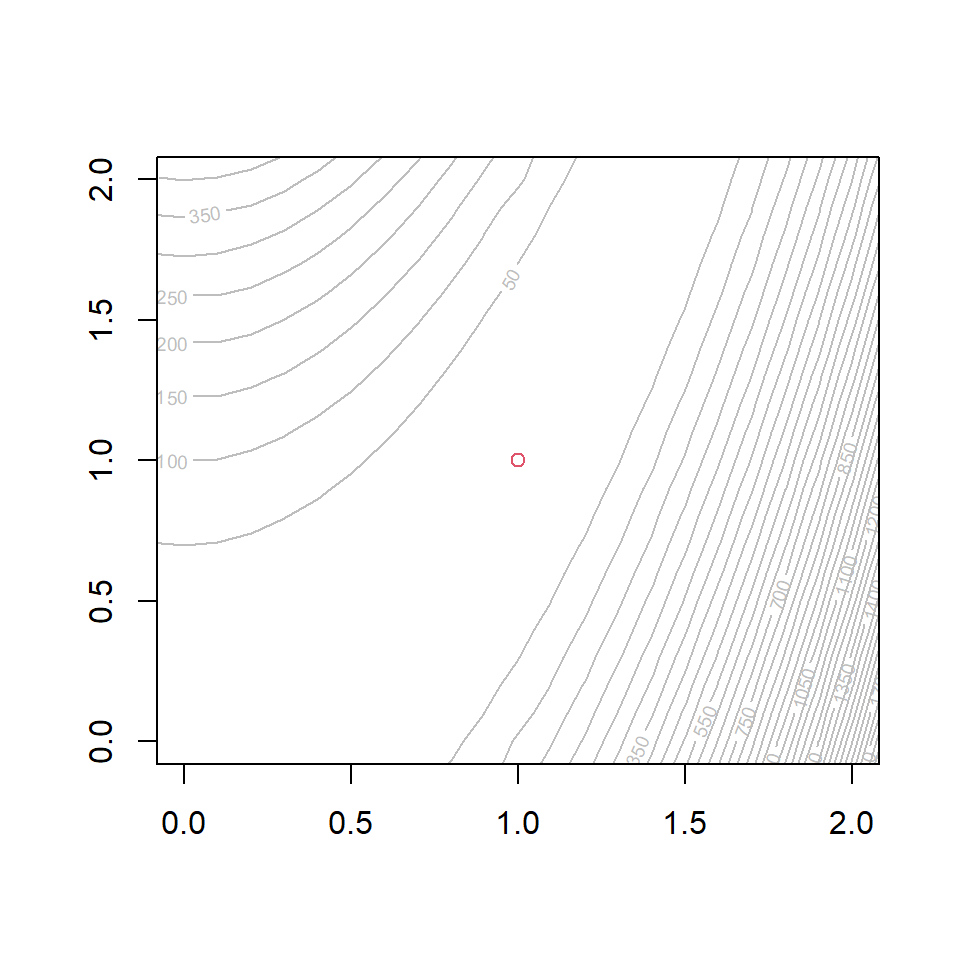

```r
contour(x1, x2, y, col="gray", nlevels = 200, xlim=c(0, 2), ylim=c(0, 2))
points(res$par[1], res$par[2], col=2)
```

Como podemos maximizar uma função?

Considere os dados abaixo seguindo distribuição de Poisson. Note que para maximizar bastar definir a função a ser maximizada com sinal negativo.

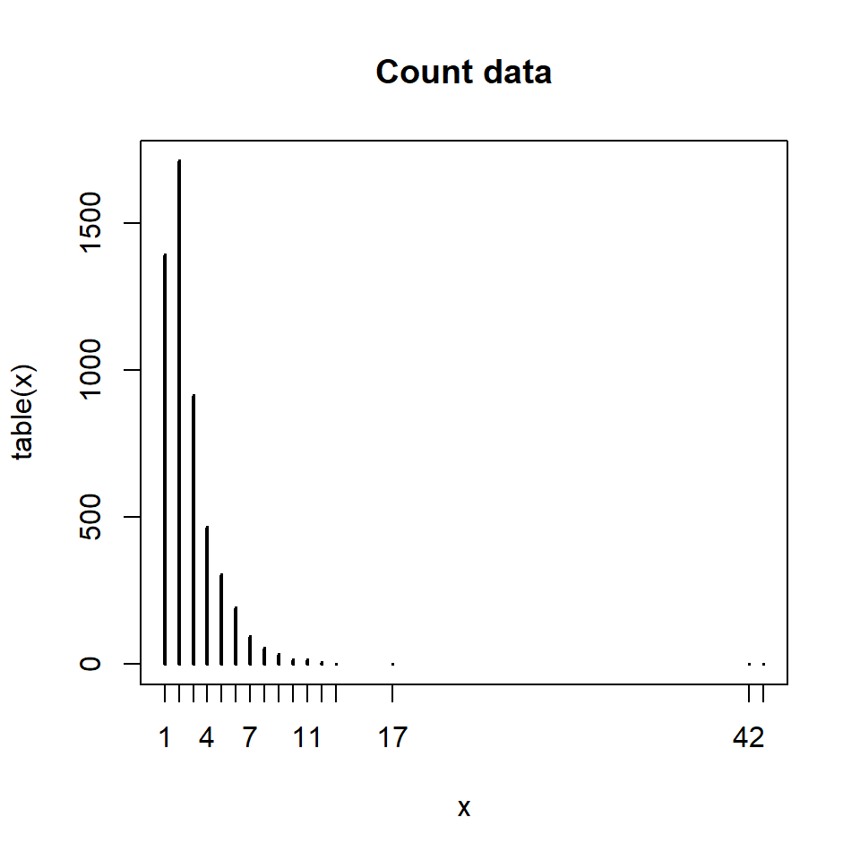

```r
obs = c(1, 2, 3, 4, 5, 6, 7, 8, 9, 10, 11, 12, 13, 17, 42, 43)
freq = c(1392, 1711, 914, 468, 306, 192, 96, 56, 35, 17, 15, 6, 2, 2, 1, 1)
x <- rep(obs, freq)
plot(table(x), main="Count data")
```

```r
##  função de log-verossimilhança
fc = function(x, lamb){
  sum(dpois(x, lamb, log=T))
}

# Minimizando
res = optim(par = 2,  fc, x = x, control=list(fnscale=-1))
res
```

```
## $par
## [1] 2.703516
##
## $value
## [1] -9966.067
##
## $counts
## function gradient
##       24       NA
##
## $convergence
## [1] 0
##
## $message
## NULL
```

```r
## Comparando com uma função pronta para encontrar a estimativas do parâmetro da Poisson
library(MASS)
fitdistr(x, "Poisson")
```

```
##      lambda
##   2.70368239
##  (0.02277154)
```

Será que o resultado faz sentido?

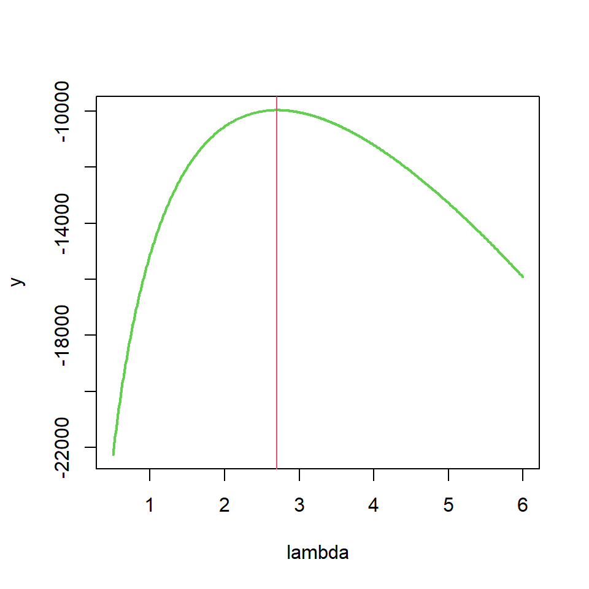

```r
lambda = y = seq(0.5, 6, by=0.01)
for(i in 1:length(lambda)){
  y[i] = fc(x, lambda[i])
}

plot(lambda, y, type = "l", col = 3, lwd=2)

abline(v=res$par, col = 2)
```

## Encontrando raizes de equações

## Encontrando raizes de equações

Qual a utilidade?

- Também pode ser utilizado para encontrar pontos de mínimo ou de máximo, por exemplo!

A função *uniroot* pode ser utilizada para encontrar uma raiz de uma equação.

```r
## Para uma reta
f <- function (x, a){ 3*x - a}
x = seq(0, 5, by=0.1)
plot(x, f(x, 2), type="l", lwd=2)
abline(h=0, lty=2, col=3)


res = uniroot(f, c(0, 10), tol = 0.0001, a = 2)
res
```

```
## $root
## [1] 0.6666667
##
## $f.root
## [1] 0
##
## $iter
## [1] 1
##
## $init.it
## [1] NA
##
## $estim.prec
## [1] 9.333333
```

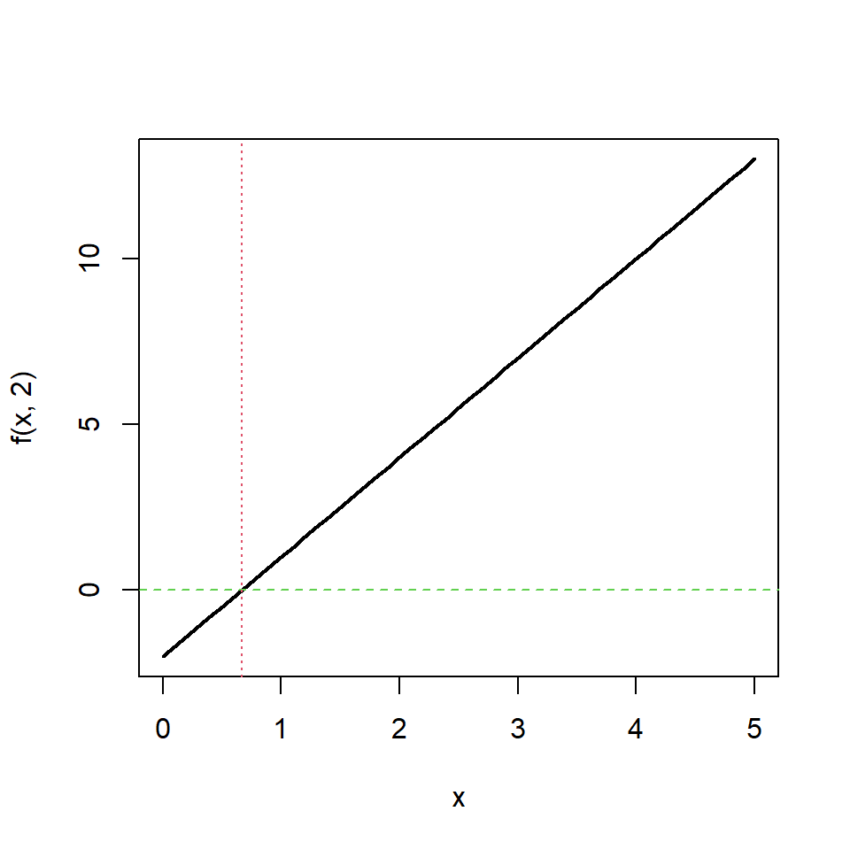

```r
abline(v=res$root, lty = 3, col=2)
```

```r
## Para uma parabola
f1 <- function (x, a, b, c ){ a*x^2 + b*x + c}
x = seq(-8, 5, by=0.1)
y = f1(x, a = 1, b = 3, c = -2)
plot(x, y, type="l", lwd=2)
abline(h=0, lty=2, col=3)


# Primeira raiz
res = uniroot(f1, lower = -0, upper = 1, a = 1, b = 3, c = -2)
res
```

```
## $root
## [1] 0.5615696
##
## $f.root
## [1] 6.91674e-05
##
## $iter
## [1] 4
##
## $init.it
## [1] NA
##
## $estim.prec
## [1] 6.103516e-05
```

```r
abline(v=res$root, lty = 3, col=2)


# Segunda raiz
res = uniroot(f1, lower = -8, upper = -2, a = 1, b = 3, c = -2)
res
```

```
## $root
## [1] -3.561534
##
## $f.root
## [1] -7.741396e-05
##
## $iter
## [1] 8
##
## $init.it
## [1] NA
##
## $estim.prec
## [1] 6.103516e-05
```

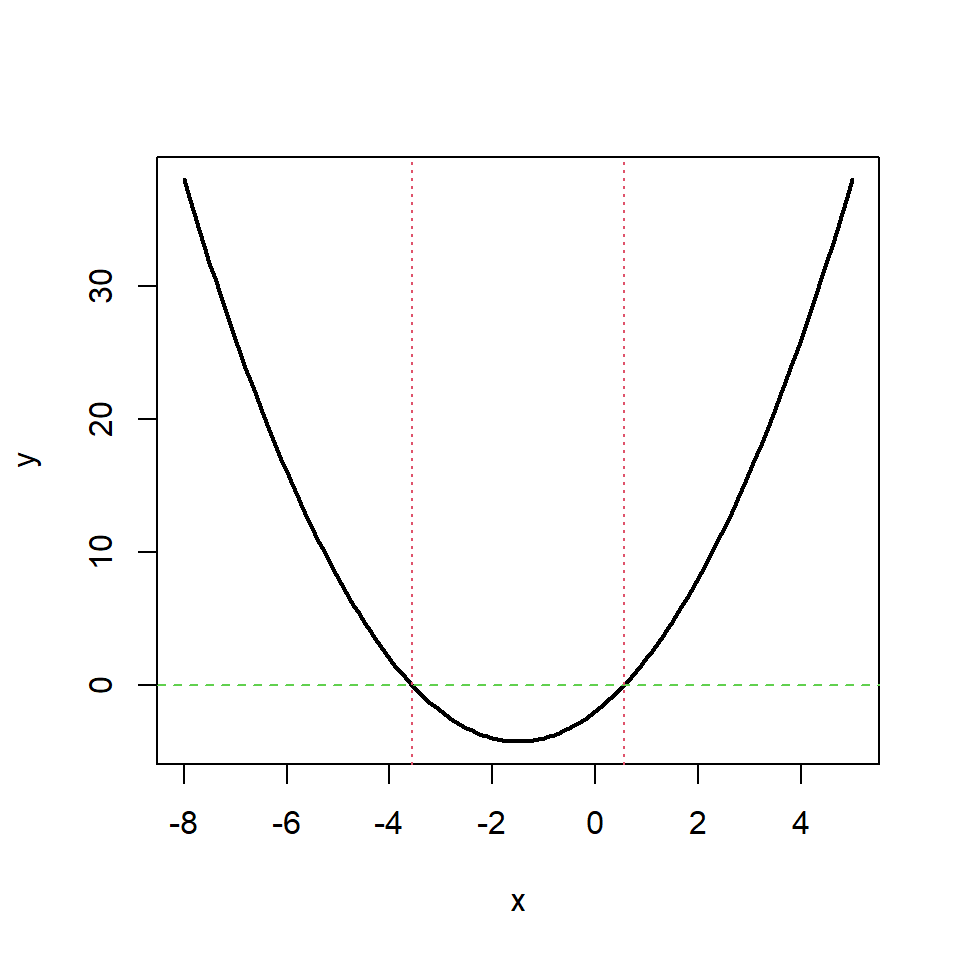

```r
abline(v=res$root, lty = 3, col=2)
```

```r
## Para polinômios podemos utilizar
polyroot(c(-2,3,1))
```

```
## [1]  0.5615528+0i -3.5615528-0i
```

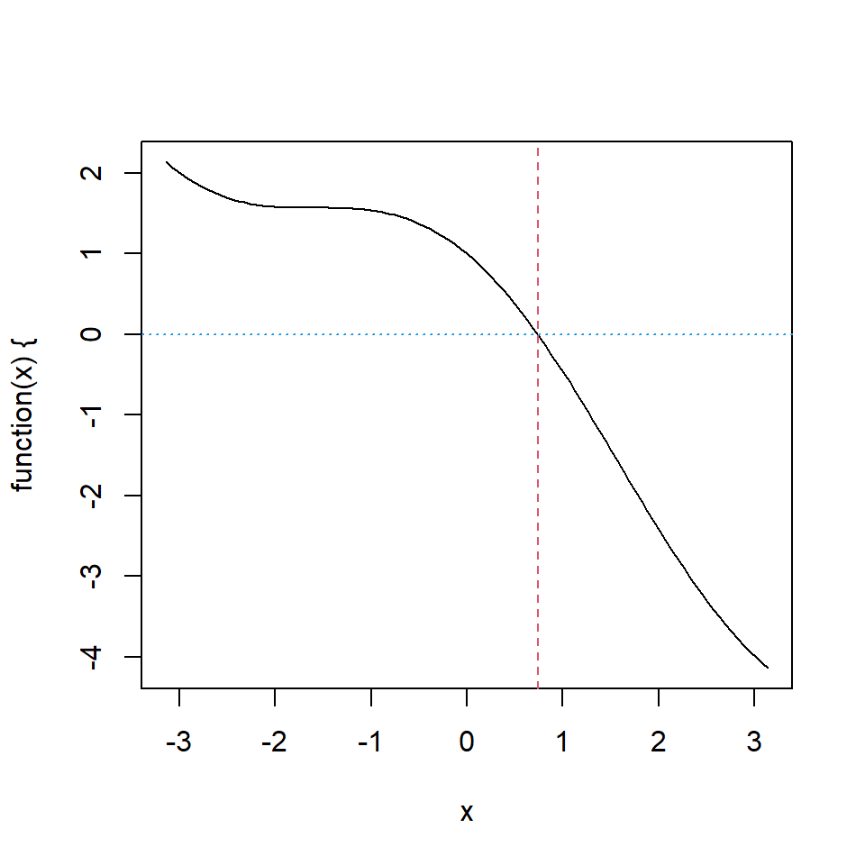

```r
## Outro exemplo
plot(function(x){cos(x) - x}, from = -pi, to = pi)

raiz = uniroot(function(x) cos(x) - x, lower = -pi, upper = pi, tol = 1e-9)$root

abline(v=raiz, lty=2, col=2)
abline(h=0, lty=3, col=4)
```

Para encontrar múltiplas raizes podemos utilizar funções do pacote rootSolve.

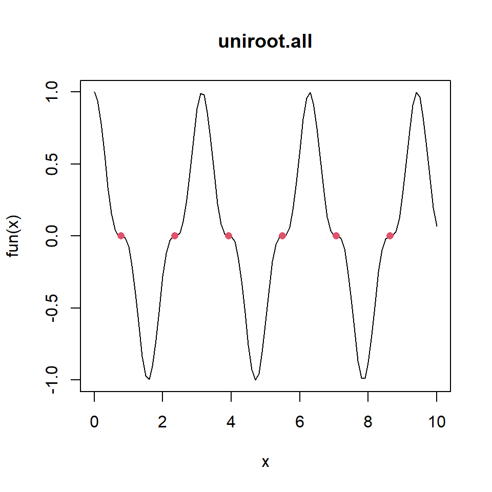

```r
require(rootSolve)

# Usando uniroot.all- para raizes de uma equação
fun <- function (x) cos(2*x)^3

curve(fun(x), 0, 10, main = "uniroot.all")

All <- uniroot.all(fun, c(0, 10))
points(All, y = rep(0, length(All)), pch = 16, cex = 1, col=2)
```

```r
## Usando o multiroot - para raizes de n equações - Exemplo 1
model <- function(x) c(F1 = x[1]^2+ x[2]^2 -1,
                       F2 = x[1]^2- x[2]^2 +0.5)

ss <- multiroot(f = model, start = c(1, 1))
ss
```

```
## $root
## [1] 0.5000000 0.8660254
##
## $f.root
##           F1           F2
## 2.323138e-08 2.323308e-08
##
## $iter
## [1] 5
##
## $estim.precis
## [1] 2.323223e-08
```

```r
## Exemplo 2

model <- function(x) c(F1 = x[1] + x[2] + x[3]^2 - 12,
                       F2 = x[1]^2 - x[2] + x[3] - 2,
                       F3 = 2 * x[1] - x[2]^2 + x[3] - 1 )

# first solution
ss <- multiroot(f = model, start = c(1, 1, 1))
ss
```

```
## $root
## [1] 1 2 3
##
## $f.root
##            F1            F2            F3
##  3.087877e-10  4.794444e-09 -8.678146e-09
##
## $iter
## [1] 6
##
## $estim.precis
## [1] 4.593792e-09
```

```r
# second solution; use different start values
ss <- multiroot(model, c(0, 0, 0))
ss
```

```
## $root
## [1] -0.2337207  1.3531901  3.2985649
##
## $f.root
##            F1            F2            F3
##  1.092413e-08  1.920978e-07 -4.850423e-08
##
## $iter
## [1] 10
##
## $estim.precis
## [1] 8.384205e-08
```

## Inferência para uma população

## Intervalo de confiança para $\mu$ quando $\sigma^2$ é conhecido

Suposições:

- Variância populacional $\sigma^2$ conhecida;
- Os dados tem distribuição Normal ou a amostra é grande.

O intervalo de $\gamma 100\%$ de confiança é dado por

$$IC(\mu,\gamma)=\left[\bar{x}-z_{\gamma}\frac{\sigma}{\sqrt{n}},\ \ \bar{x}+z_{\gamma}\frac{\sigma}{\sqrt{n}}\right],$$
em que $z_{\gamma}$ é o valor da distribuição $N(0,1)$ tal que $P(Z<z_{\gamma})=\frac{1+\gamma}{2}$.

**Exemplo:** Sabe-se que o consumo mensal per capita de um determinado produto tem distribuição normal com desvio padrão de 2kg. Foi realizada uma pesquisa de mercado com 25 indivíduos dados a seguir:

```
9.8 8.5 7.0 10.4 8.9 7.9 5.9 7.7 8.8 7.7 7.9 5.1
9.9 7.6 8.4 3.7 6.8 7.5 8.5 5.1 7.6 5.0 6.1 6.1 10.2
```

Deseja-se obter um intervalo de 95% de confiança para o consumo médio mensal per capita.

Como fazer no R?

- Fazendo as contas passo a passo, utilizando o R como uma calculadora;
- Construir uma função;
- Usar a função z.test do pacote ``TeachingDemos´´.

No R:

```r
dados=c(9.8, 8.5, 7.0, 10.4, 8.9, 7.9, 5.9, 7.7, 8.8, 7.7, 7.9, 5.1,
9.9, 7.6, 8.4, 3.7, 6.8, 7.5, 8.5, 5.1, 7.6, 5.0, 6.1, 6.1, 10.2)


## Fazendo passo a passo
v = 4 ## Valor assumido para variância populacional

n <- length(dados)
m <- mean(dados)

## Intervalo de Confiança
gama = 0.95
probs = c(((1-gama)/2), (1-(1-gama)/2))
IC <- m + qnorm(probs) * sqrt(v/n)
IC
```

```
## [1] 6.740014 8.307986
```

```r
## Escrevendo uma funcao
ic.m <- function(x, var.pop,  conf = 0.95) {
  n <- length(x)
  media <- mean(x)
  probs = c(((1-conf)/2), (1-(1-conf)/2))
  quantis <- qnorm(probs)
  ic <- media + quantis * sqrt(var.pop/n)
  return(ic)
}

## 95% de confiança
ic.m(dados, var.pop = 4)
```

```
## [1] 6.740014 8.307986
```

```r
## 99% de confiança
ic.m(dados, var.pop = 4, conf = 0.99)
```

```
## [1] 6.493668 8.554332
```

E necessário programar tudo isso?

```r
## Usando pacote
require(TeachingDemos)
z.test(dados, mu=8, sd=2)$conf.int
```

```
## [1] 6.740014 8.307986
## attr(,"conf.level")
## [1] 0.95
```

## Teste de hipóteses para média populacional assumindo variância conhecida

**Suposições:** Distribuição normal é adequada para os dados, ou a amostra é grande o suficiente, e a variância populacional $\sigma^2$ é conhecida.

A estatística de teste é

$$Z=\frac{\bar{X}-\mu_0}{\sigma/\sqrt{n}}$$
Assumindo $H_0$ verdadeira, a estatística de teste tem distribuição $N(0,1)$, pois $\bar{X}\sim N(\mu_0,\sigma^2/n)$.

**Exemplo:**

Sabe-se que o consumo mensal per capita de um determinado produto tem distribuição normal com desvio padrão de 2kg. A diretoria de uma firma que fabrica esse produto resolveu que retiraria o produto da linha de produção se a média de consumo per capita fosse menor que 8kg. Caso contrário, continuaria a fabricá-lo. Foi realizada uma pesquisa de mercado com 25 indivíduos dados a seguir:

9.8 8.5 7.0 10.4 8.9 7.9 5.9 7.7 8.8 7.7 7.9 5.1 9.9 7.6 8.4 3.7 6.8 7.5 8.5 5.1 7.6 5.0 6.1 6.1 10.2

Qual a decisão da firma a 5% de significância?

```r
# Fazendo o teste de hipóteses
z.test(dados, mu=8, alternative="less", sd=2)
```

```
##
##  One Sample z-test
##
## data:  dados
## z = -1.19, n = 25.0, Std. Dev. = 2.0, Std. Dev. of the sample mean =
## 0.4, p-value = 0.117
## alternative hypothesis: true mean is less than 8
## 95 percent confidence interval:
##      -Inf 8.181941
## sample estimates:
## mean of dados
##         7.524
```

## Argumentos e resultados das funções para intervalos de confiança e testes de hipóteses

**Quase todas as funções possuem os seguintes resultados:**

- **p-value:** é o resultado do p-valor do teste que foi executado;
- **statistic:** o valor da estatística em uso (t-Student, normal, F, qui-quadrado, etc)
- **parameter:** são os parâmetros utilizados para fazer o teste.
- **estimate:** valor estimado da amostra a ser testado
- **alternative:** descrição da hipótese alternativa
- **conf.int:** nível de confiança do teste. Por default, o R adota conf.int = 0.95

Os argumentos e resultados podem variar de função para função. Dessa forma, sempre consulte o help para mais informações.

## Intervalo de confiança para $\mu$ quando $\sigma^2$ é desconhecido

Neste caso, usamos o desvio padrão amostral e o intervalo de $\gamma 100\%$ de confiança é dado por

$$IC(\mu,\gamma)=\left[\bar{x}-t_{\gamma}\frac{s}{\sqrt{n}},\ \ \bar{x}+t_{\gamma}\frac{s}{\sqrt{n}}\right],$$
onde $t_{\gamma}$ é o valor encontrado na tabela da distribuição $t$-Student com $n-1$ graus de liberdade tal que $P(T>t_{\gamma})=\frac{1-\gamma}{2}$.

**Exemplo:** O tempo de reação de um novo medicamento pode ser considerado como tendo distribuição Normal e deseja-se fazer inferência sobre a média que é desconhecida obtendo um intervalo de confiança. Vinte pacientes foram sorteados e tiveram seu tempo de reação anotado. Os dados foram os seguintes (em minutos):

```
    2.9 3.4 3.5 4.1 4.6 4.7 4.5 3.8 5.3 4.9
    4.8 5.7 5.8 5.0 3.4 5.9 6.3 4.6 5.5 6.2
```

No R:

```r
### Com variância populacional desconhecida
## Intervalo de confiança e teste de hipoteses

## Dados
tempo <- c(2.9, 3.4, 3.5, 4.1, 4.6, 4.7, 4.5, 3.8, 5.3, 4.9, 4.8,
           5.7, 5.8, 5, 3.4, 5.9, 6.3, 4.6, 5.5, 6.2)



## Obtendo o IC através da função que realiza teste de hipóteses
t.test(tempo)
```

```
##
##  One Sample t-test
##
## data:  tempo
## t = 21.305, df = 19, p-value = 1.006e-14
## alternative hypothesis: true mean is not equal to 0
## 95 percent confidence interval:
##  4.278843 5.211157
## sample estimates:
## mean of x
##     4.745
```

```r
## Vendo apenas o IC
res = t.test(tempo)
res$conf.int
```

```
## [1] 4.278843 5.211157
## attr(,"conf.level")
## [1] 0.95
```

## Teste de hipóteses para média populacional $\mu$ com $\sigma^2$ desconhecido

**Suposições:** Os dados são normalmente distribuídos, mas não conhecemos a variância populacional $\sigma^2$.

A estatística de teste é

$$T=\frac{\bar{X}-\mu_0}{s/\sqrt{n}}.$$
Assumindo $H_0$ verdadeira, a estatística de teste tem distribuição $t$-Student com $n-1$ graus de liberdade.

**Exemplo:** O site mercado imobiliário afirma que o preço médio de apartamentos no Barreiro é de 195 mil reais. O PROCON de Belo Horizonte diz que os preços dos imóveis naquela região tem preços maiores do que 195 mil reais. Para checar esta informação o procon colheu uma amostra dos preços de vendas de 20 imoveis vendidas no Barreiro:

```
        198; 185; 205,2; 225,3; 206,7; 201,85; 200; 189; 192,1; 200,4
        302; 195; 215,4; 235,3; 216,3; 191,85; 174,6; 199; 195,4; 202,9
```

Teste a afirmação do PROCON usando 10% de significância.

```r
    amostra = c(198, 185, 205.2, 225.3, 206.7, 201.85, 200, 189, 192.1, 200.4,
                302, 195, 215.4, 235.3, 216.3, 191.85, 174.6, 199, 195.4, 202.9)
                t.test(amostra, mu=195, alternative="greater")
```

```
##
##  One Sample t-test
##
## data:  amostra
## t = 1.9633, df = 19, p-value = 0.03221
## alternative hypothesis: true mean is greater than 195
## 95 percent confidence interval:
##  196.3792      Inf
## sample estimates:
## mean of x
##   206.565
```

## Proporção populacional

Consideremos $X_i$ a variável aleatória que representa a presença (ou não) de determinada característica para a $i$-ésima observação.

- Cada variável aleatória $X_i, i = 1,\ldots,n$, tem distribuição de Bernoulli com parâmetro $p$, com média $p$ e variância $p(1-p)$.
- Diferentes metodologias podem ser consideradas para construção de intervalos de confiança e testes de hipóteses.

**Exemplo:** Numa pesquisa com 50 eleitores, o candidato José João obteve 0,34 da preferência dos eleitores. Construa, para a confiança 94%, os intervalos de confiança otimista e conservador para a proporção de votos a serem recebidos pelo candidato mencionado, supondo que a eleição fosse nesse momento.

```r
## Preferencia de votos do José João
n = 50
phat = 0.34
k = n*phat
```

```r
## Podemos construir intervalos de confiança e testes de hipóteses manualmente seguindo as metodologias apresentadas nos livros de estatística básica.
# Abordagem otimista
SE = sqrt(phat*(1-phat)/n)
E = qnorm(.975)*SE; E
```

```
## [1] 0.131303
```

```r
IC1 = round(phat + c(-E, E),4)
IC1
```

```
## [1] 0.2087 0.4713
```

```r
# Abordagem conservadora
SE = sqrt(1/(4*n))
E = qnorm(.975)*SE; E
```

```
## [1] 0.1385904
```

```r
IC2 = round(phat + c(-E, E),4)
IC2
```

```
## [1] 0.2014 0.4786
```

Também podemos utilizar a função prop.test. Ao utilizar esta função, não é efetuado o mesmo teste que aparecem nos livros de estatística básica.

```r
#Sem correcao de continuidade:
prop.test(x = k, n = n, correct = FALSE, conf.level = 0.94)
```

```
##
##  1-sample proportions test without continuity correction
##
## data:  k out of n, null probability 0.5
## X-squared = 5.12, df = 1, p-value = 0.02365
## alternative hypothesis: true p is not equal to 0.5
## 94 percent confidence interval:
##  0.2283482 0.4727952
## sample estimates:
##    p
## 0.34
```

```r
#Com correção de continuidade:
prop.test(x = k, n = n, correct = TRUE, conf.level=0.94)
```

```
##
##  1-sample proportions test with continuity correction
##
## data:  k out of n, null probability 0.5
## X-squared = 4.5, df = 1, p-value = 0.03389
## alternative hypothesis: true p is not equal to 0.5
## 94 percent confidence interval:
##  0.2198449 0.4829145
## sample estimates:
##    p
## 0.34
```

Também podemos ter a situação em que temos uma tabela com os resultados:

```r
dados <- c(rep("sim", 120), rep("não", 80))
prop.test(x = table(dados), alternative="two.sided", conf.level = 0.94, p=0.7)
```

```
##
##  1-sample proportions test with continuity correction
##
## data:  table(dados), null probability 0.7
## X-squared = 84.292, df = 1, p-value < 2.2e-16
## alternative hypothesis: true p is not equal to 0.7
## 94 percent confidence interval:
##  0.3347410 0.4688671
## sample estimates:
##   p
## 0.4
```

Por último, podemos efetuar o teste binomial exato utilizando a função binom.test:

```r
binom.test(x = k, n=n, alternative="two.sided", conf.level = 0.94, p=0.7)
```

```
##
##  Exact binomial test
##
## data:  k and n
## number of successes = 17, number of trials = 50, p-value = 1.791e-07
## alternative hypothesis: true probability of success is not equal to 0.7
## 94 percent confidence interval:
##  0.2163828 0.4820349
## sample estimates:
## probability of success
##                   0.34
```

```r
# Vários outros intervalos podem ser obtidos
library(binom)
binom.confint(x=k, n=n, conf.level = 0.95)
```

```
##           method  x  n      mean     lower     upper
## 1  agresti-coull 17 50 0.3400000 0.2238941 0.4789371
## 2     asymptotic 17 50 0.3400000 0.2086970 0.4713030
## 3          bayes 17 50 0.3431373 0.2167061 0.4729678
## 4        cloglog 17 50 0.3400000 0.2137049 0.4703930
## 5          exact 17 50 0.3400000 0.2120547 0.4876525
## 6          logit 17 50 0.3400000 0.2229732 0.4804687
## 7         probit 17 50 0.3400000 0.2204090 0.4784223
## 8        profile 17 50 0.3400000 0.2190717 0.4769531
## 9            lrt 17 50 0.3400000 0.2190585 0.4769669
## 10     prop.test 17 50 0.3400000 0.2159464 0.4885541
## 11        wilson 17 50 0.3400000 0.2243695 0.4784617
```

## Para variância populacional

Consideremos uma amostra aleatória $X_1,\ldots,X_n$ de tamanho $n$ de uma população com distribuição normal com média $\mu$ e variância $\sigma^2$.

- Neste caso, para testar hipóteses para uma variância populacional utilizamos a estatística:

  $$Q=\frac{(n-1)s^2}{\sigma^2}\sim\chi_{n-1}^2.$$
- Para o cálculo do intervalo de confiança, temos que:

$$IC(\sigma^2,1-\alpha)=\left(\frac{(n-1)s^2}{Q_{1-\alpha/2}},\frac{(n-1)s^2}{Q_{\alpha/2}}\right),$$
em que $Q_{\alpha/2}$ e $Q_{1-\alpha/2}$ são tais que $\mathbb{P}(Q < Q_{\alpha/2})=\alpha/2$ e $\mathbb{P}(Q > Q_{\alpha/2})=\alpha/2$.

**Exemplo:** O peso de componentes mecânicos produzidos por uma determinada empresa é uma variável aleatória que se supõe ter distribuição normal. Pretende-se estudar a variabilidade do peso dos referidos componentes. Para isso, uma amostra de tamanho 11 foi obtida,cujos valores em grama são: 98 97 102 100 98 101 102 105 95 102 100.

Para realizar o teste e calcular o intervalo de confiança, usaremos o pacote EnviStats e a função varTest().

```r
dados_peso <- c(98, 97, 102, 100, 98, 101, 102, 105, 95, 102, 100)
varTest(dados_peso, sigma.squared = 0.5)
```

```
##
##  Chi-Squared Test on Variance
##
## data:  dados_peso
## Chi-Squared = 160, df = 10, p-value < 2.2e-16
## alternative hypothesis: true variance is not equal to 0.5
## 95 percent confidence interval:
##   3.905644 24.638334
## sample estimates:
## variance
##        8
```

Acima, estamos testando se a variância é igual a 0.5. Então, pelo p-valor ao nível de significância de 5%, rejeitamos a hipótese nula, ou seja, temos evidêcia amostrais que a variância é diferente de 0.5.

## Inferência para duas populações

## Inferência para duas populações

Abaixo são apresentados exemplos de uso das funções para obtenção de testes e intervalos de confiança para médias, proporções e variâncias populacionais.

- O uso das funções é similar ao apresentado anteriormente e detalhes teóricos devem ser buscados em livros didáticos.

### Médias populacionais

```r
m1 <- c(0.9, 2.5, 9.2, 3.2, 3.7, 1.3, 1.2, 2.4, 3.6, 8.3)
m2 <- c(5.3, 6.3, 5.5, 3.6, 4.1, 2.7, 2, 1.5, 5.1, 3.5)
t.test(m1, m2, var.eq = TRUE, conf = 0.99) ## Assumindo variancias populacionais iguais
```

```
##
##  Two Sample t-test
##
## data:  m1 and m2
## t = -0.31724, df = 18, p-value = 0.7547
## alternative hypothesis: true difference in means is not equal to 0
## 99 percent confidence interval:
##  -3.324208  2.664208
## sample estimates:
## mean of x mean of y
##      3.63      3.96
```

```r
t.test(m1, m2, var.eq = FALSE, conf = 0.99) ## Assumindo variancias populacionais diferentes
```

```
##
##  Welch Two Sample t-test
##
## data:  m1 and m2
## t = -0.31724, df = 14.028, p-value = 0.7557
## alternative hypothesis: true difference in means is not equal to 0
## 99 percent confidence interval:
##  -3.425609  2.765609
## sample estimates:
## mean of x mean of y
##      3.63      3.96
```

*Observação:* Para amostras pareadas é necessário utilizar o argumento paired = TRUE na função t.test

### Para duas proporções

```r
prop.test(x = c(253,196), n=c(300,300))
```

```
##
##  2-sample test for equality of proportions with continuity correction
##
## data:  c(253, 196) out of c(300, 300)
## X-squared = 27.753, df = 1, p-value = 1.379e-07
## alternative hypothesis: two.sided
## 95 percent confidence interval:
##  0.1189026 0.2610974
## sample estimates:
##    prop 1    prop 2
## 0.8433333 0.6533333
```

```r
prop.test(x = c(18,14), n=c(20,20))
```

```
##
##  2-sample test for equality of proportions with continuity correction
##
## data:  c(18, 14) out of c(20, 20)
## X-squared = 1.4063, df = 1, p-value = 0.2357
## alternative hypothesis: two.sided
## 95 percent confidence interval:
##  -0.09004558  0.49004558
## sample estimates:
## prop 1 prop 2
##    0.9    0.7
```

### Teste de igualdade de variâncias

```r
# Amostra A
ma <- c(145, 127, 136, 142, 141, 137)

# Amostra B
mb <- c(143, 128, 132, 138, 142, 132)

# Função pronta
args(var.test)
```

```
## function (x, ...)
## NULL
```

```r
# Note que esta saida nao eh muito informativa. Este tipo de resultado indica que var.test()
# eh um metodo com mais de uma funcao associada. Portanto devemos pedir os argumentos da
# funcao "default".
args(getS3method("var.test", "default"))
```

```
## function (x, y, ratio = 1, alternative = c("two.sided", "less",
##     "greater"), conf.level = 0.95, ...)
## NULL
```

```r
var.test(ma, mb)
```

```
##
##  F test to compare two variances
##
## data:  ma and mb
## F = 1.0821, num df = 5, denom df = 5, p-value = 0.9331
## alternative hypothesis: true ratio of variances is not equal to 1
## 95 percent confidence interval:
##  0.1514131 7.7327847
## sample estimates:
## ratio of variances
##           1.082056
```

## Teste Qui-quadrado

## Teste Qui-quadrado

Podemos utilizar o teste Qui-Quadrado para realizar:

- Teste de Independência
- Teste de Aderência
- Teste de Homogeneidade

### **Teste de independência**.

O teste de independência Qui-Quadrado é usado para descobrir se existe uma associação entre duas variáveis em uma tabela de contingência construída à partir de dados da amostra.

- A hipótese nula é de que as variáveis são independentes.
- A hipótese alternativa é de que as variáveis são dependentes.

Para este caso, utilizaremos o banco de dados HairEyeColor:

```r
data(HairEyeColor)
HairEyeColor
```

```
## , , Sex = Male
##
##        Eye
## Hair    Brown Blue Hazel Green
##   Black    32   11    10     3
##   Brown    53   50    25    15
##   Red      10   10     7     7
##   Blond     3   30     5     8
##
## , , Sex = Female
##
##        Eye
## Hair    Brown Blue Hazel Green
##   Black    36    9     5     2
##   Brown    66   34    29    14
##   Red      16    7     7     7
##   Blond     4   64     5     8
```

```r
## Juntando homens e mulheres
dados = HairEyeColor[, , 1] + HairEyeColor[, , 2]
```

Teste com distribuição teórica da estatística de teste:

```r
chisq.test(dados)
```

```
##
##  Pearson's Chi-squared test
##
## data:  dados
## X-squared = 138.29, df = 9, p-value < 2.2e-16
```

Teste com distribuição simulada da estatística de teste:

```r
chisq.test(dados, sim = T)
```

```
##
##  Pearson's Chi-squared test with simulated p-value (based on 2000
##  replicates)
##
## data:  dados
## X-squared = 138.29, df = NA, p-value = 0.0004998
```

### **Teste de aderência**

- Agora o objetivo é testar a adequabilidade de um modelo probabilístico a um conjunto de dados observados.

Se a variável é contínua, é necessário separá-la em faixas para executar o teste. Temos o seguindo exemplo com a distribuição exponencial:

```r
lambda_real = 2
x = rexp(100, rate = lambda_real)
quebras = c(0, 0.5, 1, 1.5, 2, +Inf)
histograma = hist(x, plot=FALSE, breaks = quebras)
histograma
```

```
## $breaks
## [1] 0.0 0.5 1.0 1.5 2.0 Inf
##
## $counts
## [1] 68 18 11  2  1
##
## $density
## [1] 1.36 0.36 0.22 0.04 0.00
##
## $mids
## [1] 0.25 0.75 1.25 1.75  Inf
##
## $xname
## [1] "x"
##
## $equidist
## [1] FALSE
##
## attr(,"class")
## [1] "histogram"
```

```r
obs = histograma$counts

lambda_est = 1/mean(x)
esp = pexp(quebras[-1], rate = lambda_est)-pexp(quebras[-length(quebras)], lambda_est)
chisq.test(obs, p=esp)
```

```
##
##  Chi-squared test for given probabilities
##
## data:  obs
## X-squared = 2.7568, df = 4, p-value = 0.5993
```

```r
chisq.test(obs,p=esp,simulate.p.value = TRUE)
```

```
##
##  Chi-squared test for given probabilities with simulated p-value (based
##  on 2000 replicates)
##
## data:  obs
## X-squared = 2.7568, df = NA, p-value = 0.6007
```

### **Teste de homogeneidade**

- Podemos testar a afirmação de que diferentes populações têm a mesma proporção de indivíduos com alguma característica.

Em um caso em que tenho dados do número de lentes oculares com e sem defeito, obtenho a seguinte tabela

```r
dados<-matrix(c(36, 25, 5, 12), nrow=2,
               dimnames = list(c("Lente tipo A",  "Lente tipo B"),
                               c("Não defeituosas", "defeituosa")))
dados
```

```
##              Não defeituosas defeituosa
## Lente tipo A              36          5
## Lente tipo B              25         12
```

O teste de homogeneidade teste a afirmação de duas populações diferentes (com defeito, sem defeito) têm a mesma proporção de lentes defeituosas. Então:

```r
chisq.test(dados)
```

```
##
##  Pearson's Chi-squared test with Yates' continuity correction
##
## data:  dados
## X-squared = 3.5612, df = 1, p-value = 0.05914
```

Dessa forma, vemos que o teste é marginalmente significativo. Ou seja, com 5% de significância não rejeitamos a hipótese nula, logo, temos evidências amostrais que a proporção de lenes defeituosas são iguais.

## Como testar normalidade?

## Um pouco sobre como avaliar normalidade nos dados

Os testes de normalidade são utilizados para verificar se a distribuição de probabilidade associada a um conjunto de dados pode ser aproximada pela distribuição normal.

No primeiro caso vamos trabalhar com dados simulados de uma distribuição normal. Para uma análise descritiva, temos que o histograma coma forma da densidade dos dados:

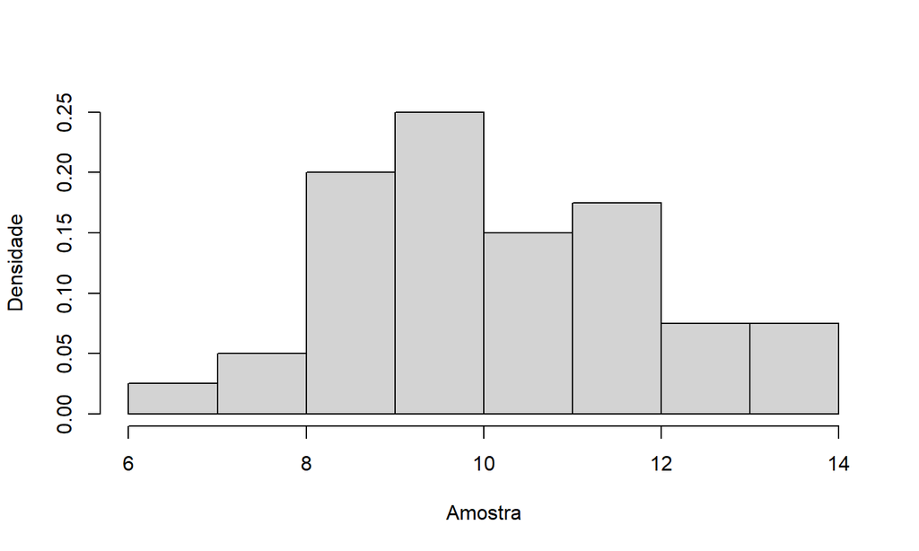

```r
x.norm <- rnorm(n=80, m=10, sd=2) ## Gerando uma amostra da distribuição Normal
hist(x.norm,probability = TRUE, main ="", ylab="Densidade", xlab = "Amostra")
```

Abaixo temos o gráfico com a distribuição acumulada dos dados, onde a linha em vermelho é a curva teórica, enquanto que os pontos são os dados simulados anteriormente.

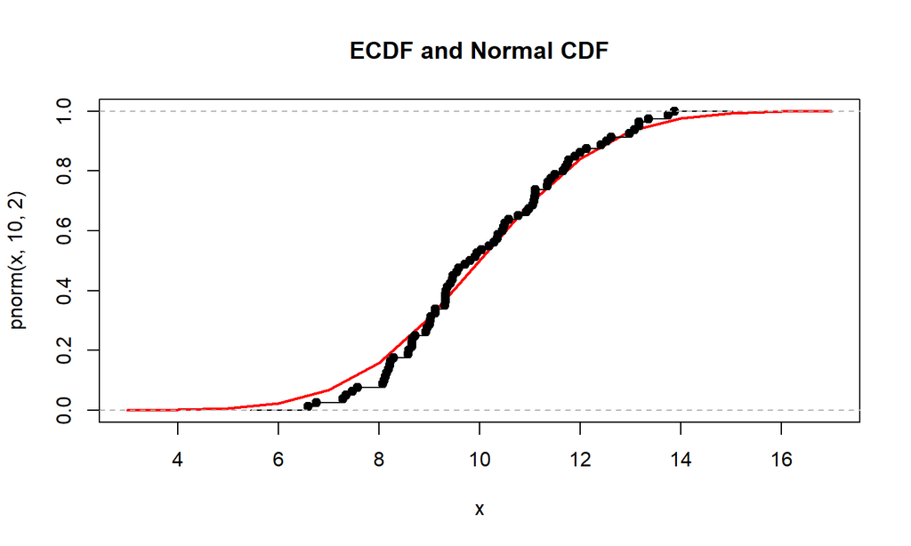

```r
x<-3:17
plot(x, pnorm(x, 10, 2), type="l", col="red", main="ECDF and Normal CDF", lwd=2)
plot(ecdf(x.norm), add=TRUE)
```

No qq-plot, o ideal é que os pontos, que representam os dados simulados, estejam sob a linha teórica vermelha, ou o mais perto possivel, sem muitos desvios.

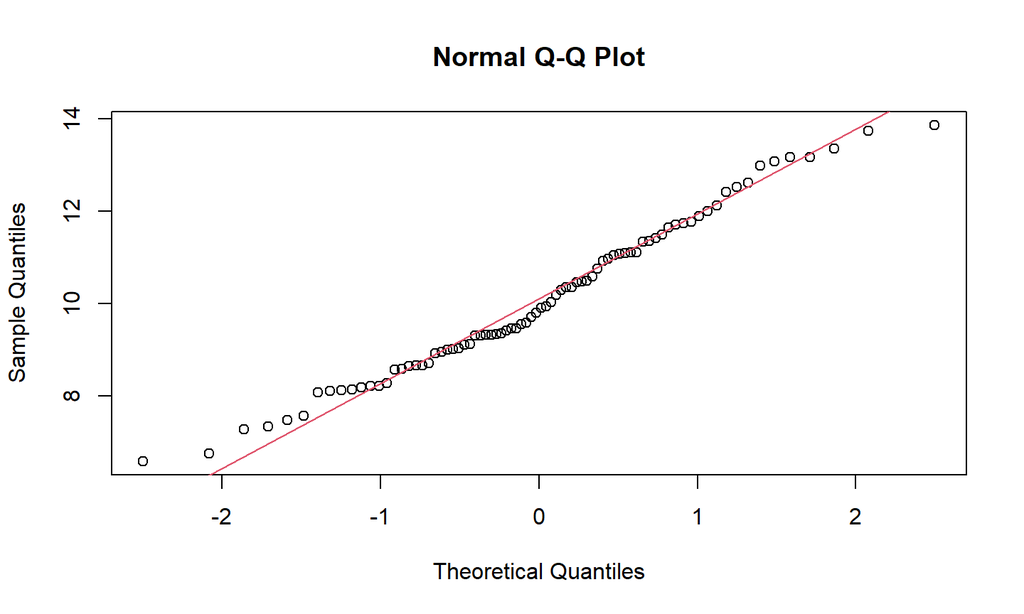

```r
qqnorm(x.norm); qqline(x.norm, col = 2) ## Fazendo um QQ-plot
```

Também é possivel usar a função qqplot para outras distribuições de probabilidade. Para isso, basta trocar “rnorm” pela distribuição que queira testar.

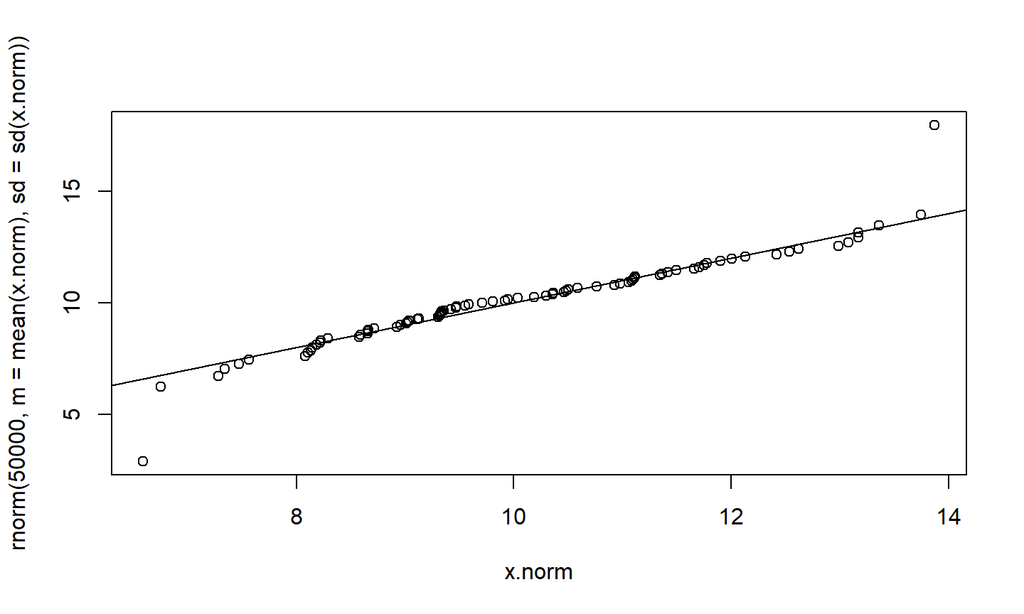

```r
qqplot(x.norm, rnorm(50000, m =mean(x.norm), sd=sd(x.norm))); abline(0, 1)
```

Vamos mostrar 2 testes de hipóteses com o objetivo de checar a normalidade dos dados:

*Shapiro-wilks:

```r
shapiro.test(x.norm)
```

```
##
##  Shapiro-Wilk normality test
##
## data:  x.norm
## W = 0.97983, p-value = 0.2379
```

- Kolmogorov-Smirnov: para este, podemos utilizar outras distribuições de probabilidade, trocando “pnorm” pelo o que você quiser testar.

```r
y <- rt(n=200, 2)
ks.test(y, 'pnorm')
```

```
##
##  One-sample Kolmogorov-Smirnov test
##
## data:  y
## D = 0.10173, p-value = 0.03187
## alternative hypothesis: two-sided
```